# VLM Wrong Predictions: attr_material_frame_tank_body [embed_only]

**Model:** VLM vs DINOv3  
**Attribute:** attr_material_frame_tank_body [embed_only]  
**Wrong assets:** 50 of 50 (100.0% asset-level error rate)

Asset 47054 2 images

Predicted: VLM: Timber/Wood | DINOv3: Box Step (conf: N/A)

Actual: Box Step

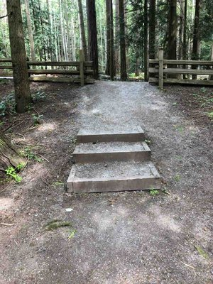

43914__AST_EX_20220601_104524.jpeg

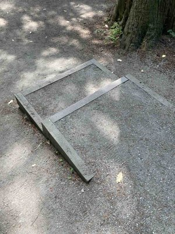

71343__AST_EX_20240725_135329.jpeg

Asset 48347 1 image

Predicted: VLM: Timber/Wood | DINOv3: Box Step (conf: N/A)

Actual: Box Step

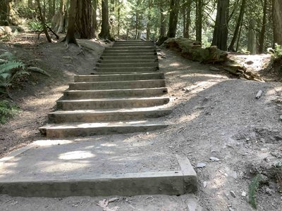

10724__AST_EX_20210805_145415.jpeg

Asset 48799 1 image

Predicted: VLM: Timber/Wood | DINOv3: Box Step (conf: N/A)

Actual: Box Step

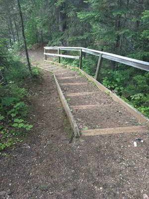

48667__AST_EX_20220622_154539.jpeg

Asset 49501 1 image

Predicted: VLM: Timber/Wood | DINOv3: Concrete (conf: N/A)

Actual: Concrete

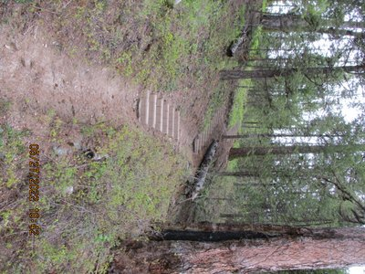

49517__IMG_5813.JPG

Asset 50514 1 image

Predicted: VLM: Timber/Wood | DINOv3: Box Step (conf: N/A)

Actual: Box Step

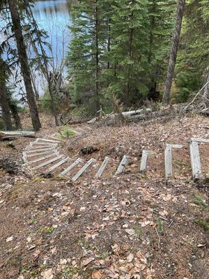

42055__AST_EX_20220511_125800.jpeg

Asset 50805 1 image

Predicted: VLM: Timber/Wood | DINOv3: Box Step (conf: N/A)

Actual: Box Step

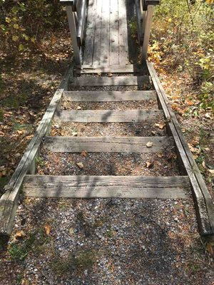

25286__AST_EX_20211002_121048.jpeg

Asset 51536 1 image

Predicted: VLM: Timber/Wood | DINOv3: Box Step (conf: N/A)

Actual: Box Step

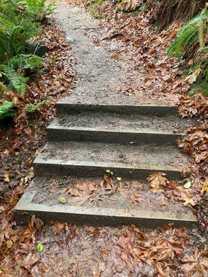

77015__AST_EX_20241106_114709.jpeg

Asset 51545 1 image

Predicted: VLM: Steel | DINOv3: Metal (conf: N/A)

Actual: Metal

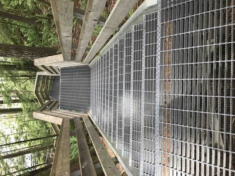

1137__AST_EX_20210617_120315.jpeg

Asset 51804 3 images

Predicted: VLM: Timber/Wood | DINOv3: Box Step (conf: N/A)

Actual: Box Step

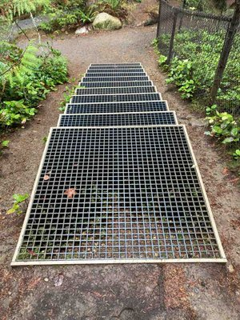

30765__AST_EX_20211103_152256.jpeg

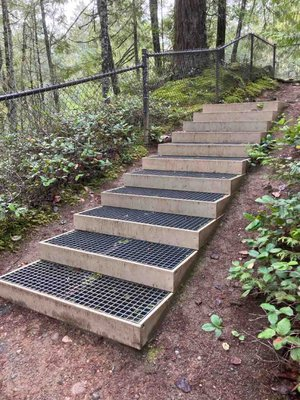

77876__AST_EX_20241128_121633.jpeg

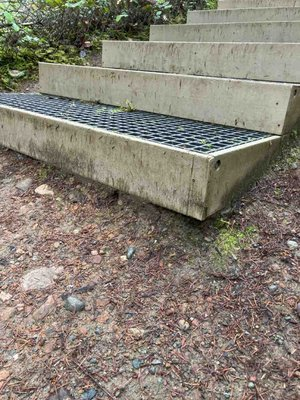

77877__AST_EX_20241128_121641.jpeg

Asset 52162 1 image

Predicted: VLM: Timber/Wood | DINOv3: Box Step (conf: N/A)

Actual: Box Step

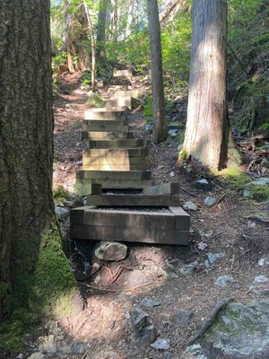

58220__AST_EX_20220807_100025.jpeg

Asset 53110 1 image

Predicted: VLM: Timber/Wood | DINOv3: Box Step (conf: N/A)

Actual: Box Step

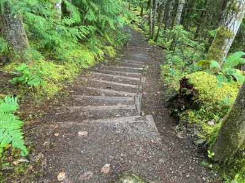

45603__AST_EX_20220609_114340.jpeg

Asset 53212 3 images

Predicted: VLM: Timber/Wood | DINOv3: Box Step (conf: N/A)

Actual: Box Step

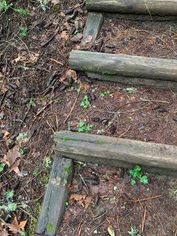

35514__AST_EX_20220121_144709.jpeg

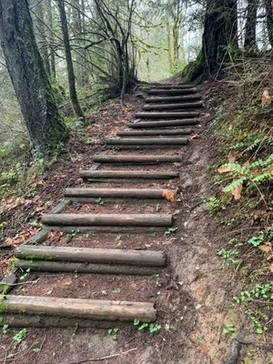

35516__AST_EX_20220121_144646.jpeg

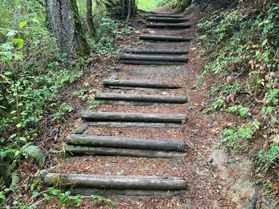

71833__AST_EX_20240730_132053.jpeg

Asset 53428 1 image

Predicted: VLM: Concrete | DINOv3: Box Step (conf: N/A)

Actual: Box Step

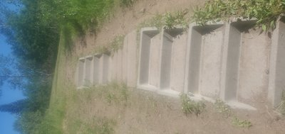

1706__MI_20210622_150104.jpg

Asset 53808 2 images

Predicted: VLM: Timber/Wood | DINOv3: Box Step (conf: N/A)

Actual: Box Step

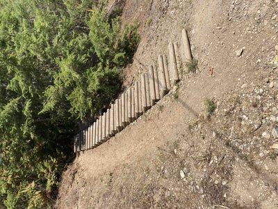

13956__AST_EX_20210812_111719.jpeg

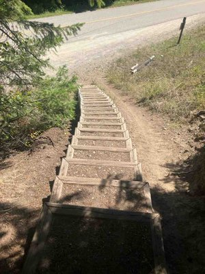

86160__AST_EX_20250811_140653.jpeg

Asset 55708 1 image

Predicted: VLM: Timber/Wood | DINOv3: Box Step (conf: N/A)

Actual: Box Step

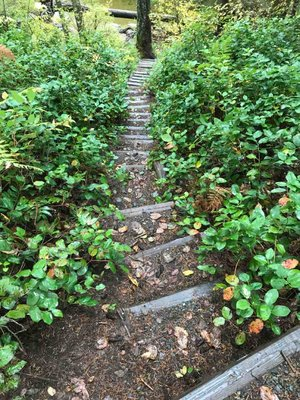

26930__AST_EX_20211014_123431.jpeg

Asset 56479 5 images

Predicted: VLM: Timber/Wood | DINOv3: Box Step (conf: N/A)

Actual: Box Step

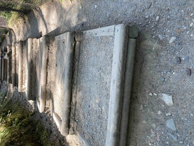

16404__AST_EX_20210819_115352.jpeg

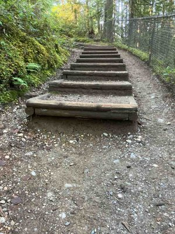

78521__AST_EX_20250121_121720.jpeg

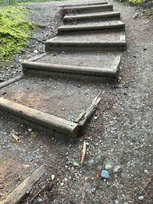

78522__AST_EX_20250121_121653.jpeg

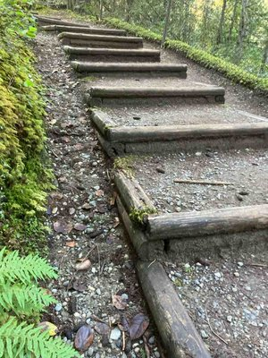

78523__AST_EX_20250121_121713.jpeg

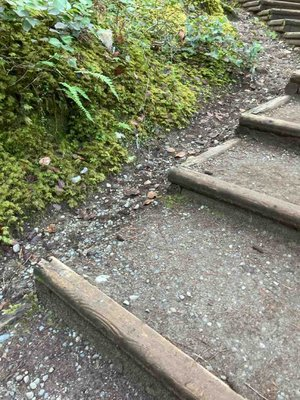

78525__AST_EX_20250121_121706.jpeg

Asset 56563 2 images

Predicted: VLM: Timber/Wood | DINOv3: Box Step (conf: N/A)

Actual: Box Step

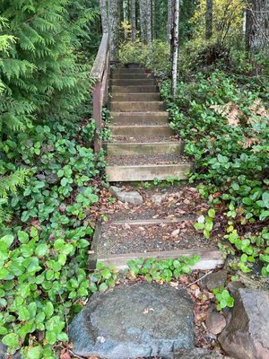

77183__AST_EX_20241107_121654.jpeg

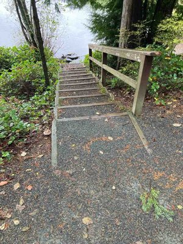

77184__AST_EX_20241107_121636.jpeg

Asset 56878 2 images

Predicted: VLM: Timber/Wood | DINOv3: Box Step (conf: N/A)

Actual: Box Step

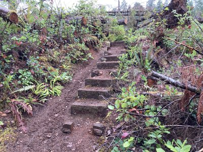

21688__IMG_0698.JPG

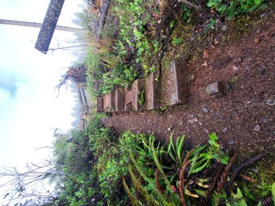

76059__s14stairs2.jpg

Asset 61221 1 image

Predicted: VLM: Timber/Wood | DINOv3: Concrete (conf: N/A)

Actual: Concrete

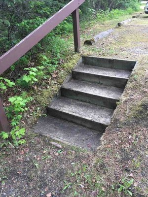

45850__AST_EX_20220610_140536.jpeg

Asset 64381 1 image

Predicted: VLM: Timber/Wood | DINOv3: Box Step (conf: N/A)

Actual: Box Step

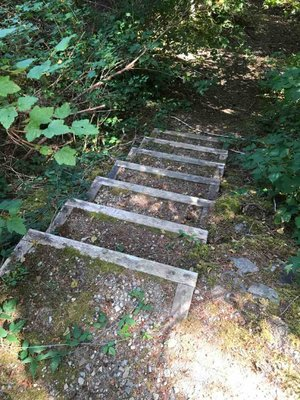

62982__AST_EX_20220902_150753.jpeg

Asset 64656 1 image

Predicted: VLM: Timber/Wood | DINOv3: Box Step (conf: N/A)

Actual: Box Step

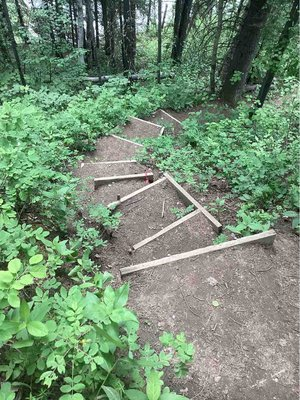

51564__AST_EX_20220704_143541.jpeg

Asset 65613 1 image

Predicted: VLM: Timber/Wood | DINOv3: Box Step (conf: N/A)

Actual: Box Step

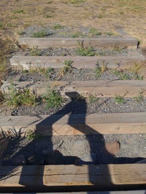

58860__MI_20220806_174255.jpg

Asset 80450 1 image

Predicted: VLM: Rock/Stone | DINOv3: Timber/Wood (conf: N/A)

Actual: Timber/Wood

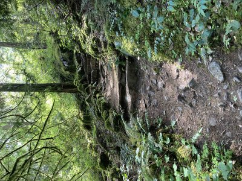

129__AST_IM_20210507_110538.jpeg

Asset 80640 2 images

Predicted: VLM: Timber/Wood | DINOv3: Box Step (conf: N/A)

Actual: Box Step

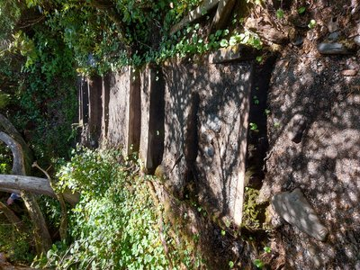

426__20210529_115321.jpg

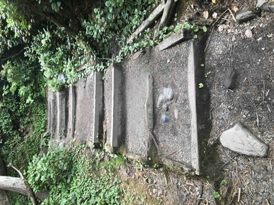

9126__AST_EX_20210723_104952.jpeg

Asset 80909 1 image

Predicted: VLM: Timber/Wood | DINOv3: Box Step (conf: N/A)

Actual: Box Step

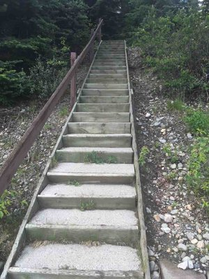

48953__AST_EX_20220621_165949.jpeg

Asset 80916 1 image

Predicted: VLM: Timber/Wood | DINOv3: Box Step (conf: N/A)

Actual: Box Step

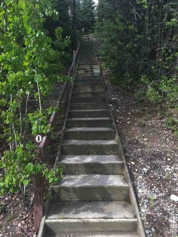

48960__AST_EX_20220621_164416.jpeg

Asset 82778 2 images

Predicted: VLM: Timber/Wood | DINOv3: Box Step (conf: N/A)

Actual: Box Step

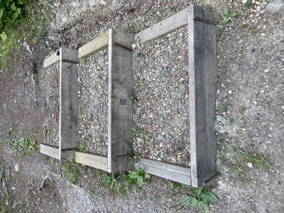

4846__AST_IM_20210709_134028.jpeg

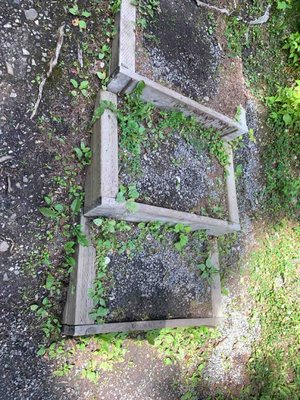

72165__AST_EX_20240729_124925.jpeg

Asset 85087 1 image

Predicted: VLM: Steel | DINOv3: Metal (conf: N/A)

Actual: Metal

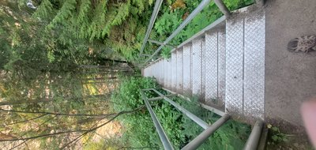

11264__MI_20210805_111305.jpg

Asset 86094 1 image

Predicted: VLM: Timber/Wood | DINOv3: Box Step (conf: N/A)

Actual: Box Step

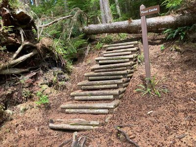

85680__AST_EX_20250730_130132.jpeg

Asset 88087 1 image

Predicted: VLM: Concrete | DINOv3: Box Step (conf: N/A)

Actual: Box Step

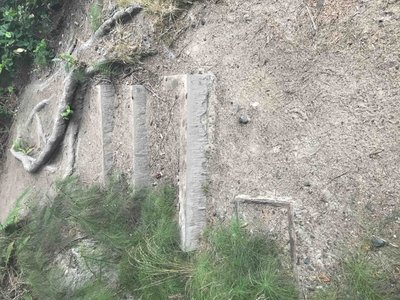

18826__AST_IM_20210826_120506.jpeg

Asset 88271 2 images

Predicted: VLM: Timber/Wood | DINOv3: Box Step (conf: N/A)

Actual: Box Step

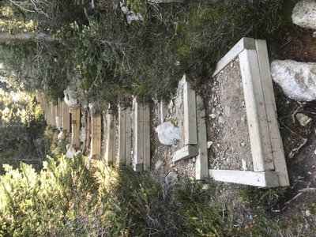

19198__AST_IM_20210829_092520.jpeg

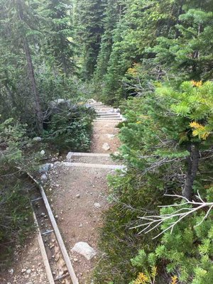

72604__AST_EX_20240817_171600.jpeg

Asset 89718 2 images

Predicted: VLM: Timber/Wood | DINOv3: Box Step (conf: N/A)

Actual: Box Step

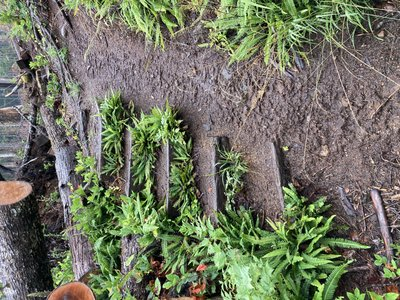

22899__IMG_0676.JPG

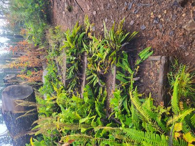

76061__s16stairs4.jpg

Asset 89732 2 images

Predicted: VLM: Timber/Wood | DINOv3: Box Step (conf: N/A)

Actual: Box Step

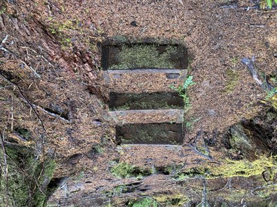

22907__IMG_0685.JPG

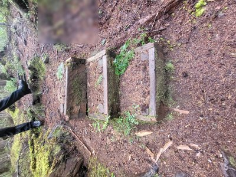

76068__s23.jpg

Asset 92005 1 image

Predicted: VLM: Timber/Wood | DINOv3: Box Step (conf: N/A)

Actual: Box Step

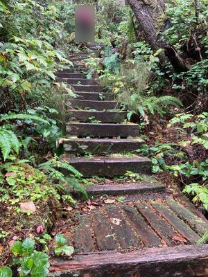

27334__AST_IM_20211013_093533.jpeg

Asset 92032 2 images

Predicted: VLM: Timber/Wood | DINOv3: Box Step (conf: N/A)

Actual: Box Step

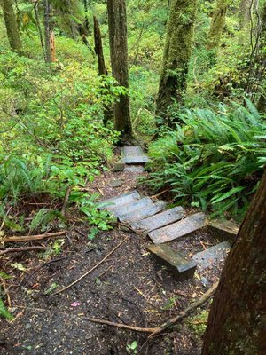

27286__AST_IM_20211013_120027.jpeg

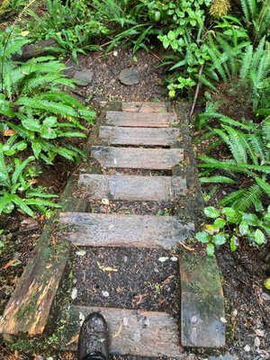

27288__AST_IM_20211013_115943.jpeg

Asset 92076 1 image

Predicted: VLM: Timber/Wood | DINOv3: Box Step (conf: N/A)

Actual: Box Step

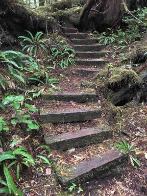

27388__AST_IM_20211013_094120.jpeg

Asset 92084 1 image

Predicted: VLM: Timber/Wood | DINOv3: Box Step (conf: N/A)

Actual: Box Step

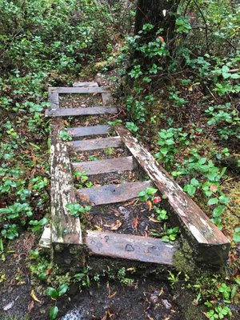

27372__AST_IM_20211013_105834.jpeg